# Practical MachineLearning Project

Kanu Dutta

Tuesday, February 10, 2015

### Abstract :-

Human Activity Recognition - HAR - has emerged as a key research area in the last years and is gaining increasing attention by the pervasive computing research community, especially for the development of context-aware systems.

Using devices such as Jawbone Up, Nike FuelBand, and Fitbit it is now possible to collect a large amount of data about personal activity relatively inexpensively.These type of devices are part of the quantified self movement a group of enthusiasts who take measurements about themselves regularly to improve their health, to find patterns in their behavior, or because they are tech geeks. One thing that people regularly do is quantify how much of a particular activity they do, but they rarely quantify how well they do it. In this project, your goal will be to use data from accelerometers on the belt, forearm, arm, and dumbell of 6 participants. They were asked to perform barbell lifts correctly and incorrectly in 5 different ways.

### Project Goals:-

The goal of your project is to predict the manner in which the exercise was done. The full description is available at the site where the data was obtained:

##### http://groupware.les.inf.puc-rio.br/har

##### Loading required libraries

```r
require(caret)
require(kernlab)
require(plyr)
require(dplyr)
require(car)
require(MASS)
require(ggplot2)
require(corrgram)
require(MASS)
require(reshape)
require(scales)
```

##### Load and Clean the data ,

```r
dataM1 <- read.csv("pml-training.csv",stringsAsFactors=FALSE)
str(dataM1)
head(dataM1)
dim(dataM1)
```

As many observation in dataset contains NAs and blank . we first find the no of NAs and blanks in the dataset using apply, and then inspect the table which shows each row consisiting of a predictor and its number of NAs.Same procedure was adopted for blanks in the data.Finally remove the predictor consisiting of high number of NAs and blanks wrt to the total observations.

```r
# removing NAs and blanks
remV1 <- as.matrix(apply(dataM1, 2, function(x) length(which(is.na(x)))))
remVn1 <- print(names(remV1[which(remV1[,1]==0),]))
myvars1 <- names(dataM1) %in% remVn1
dataM2 <- dataM1[,myvars1]
summary(dataM2)

remV2 <- as.matrix(apply(dataM2, 2, function(x) length(which(x==""))))
remVn2 <- print(names(remV2[which(remV2[,1]==0),]))
myvars2 <- names(dataM2) %in% remVn2
dataM3 <- dataM2[,myvars2]
summary(dataM3)
dataM3 <- dataM3[,-c(1,2,3,4,5,6)]
```

```r
## First six preditors has no effect on our prediction goals and hence are being removed
dataM3 <- dataM3[,-c(1,2,3,4,5,6)]
```

##### data partition for training and validation,

The split is 75% for training and 25% for validation

```r
set.seed(1234)
inTrain <- createDataPartition(y=dataM3$classe,p=0.75, list=FALSE)
training1 <- dataM3[inTrain,]
testing1 <- dataM3[-inTrain,]
dim(training1)
```

[output not shown]

```r
## centering and scaling for normalising the data

preProcValues <- preProcess(dataM3[,-54], method = c("center", "scale"))

trainTransformed <- predict(preProcValues, training1[,-54])
testTransformed <- predict(preProcValues, testing1[,-54])

trainTransformedf <- cbind(trainTransformed,training1[,54])
testTransformedf <-  cbind(testTransformed,testing1[,54])
names(trainTransformedf)[54] <- c("classe")
names(testTransformedf)[54] <- c("classe")
```

##### cross validation setting

Method = “repeatedcv”, number = 3,repeats = 1

```r
#

set.seed(32323)
folds <-  createFolds(y=trainTransformedf[,54],k=10,list=TRUE,returnTrain=TRUE)
fitControl1 <- trainControl(method = "repeatedcv", number = 3,repeats = 1)
```

#### Training the model using random forest

```r
rfH <- train(classe ~ .,data=trainTransformedf[,2:54],
             method = "rf",importance=TRUE,
              prox=TRUE,
              trControl = fitControl1)
```

```r
print(rfH)
```

```
## Random Forest
##
## 14718 samples
##    52 predictor
##     5 classes: 'A', 'B', 'C', 'D', 'E'
##
## No pre-processing
## Resampling: Cross-Validated (3 fold, repeated 1 times)
##
## Summary of sample sizes: 9812, 9812, 9812
##
## Resampling results across tuning parameters:
##
##   mtry  Accuracy   Kappa      Accuracy SD  Kappa SD
##    2    0.9888572  0.9859013  0.001294507  0.001638269
##   27    0.9892648  0.9864184  0.002051864  0.002597179
##   52    0.9834896  0.9791098  0.004594141  0.005816226
##
## Accuracy was used to select the optimal model using  the largest value.
## The final value used for the model was mtry = 27.
```

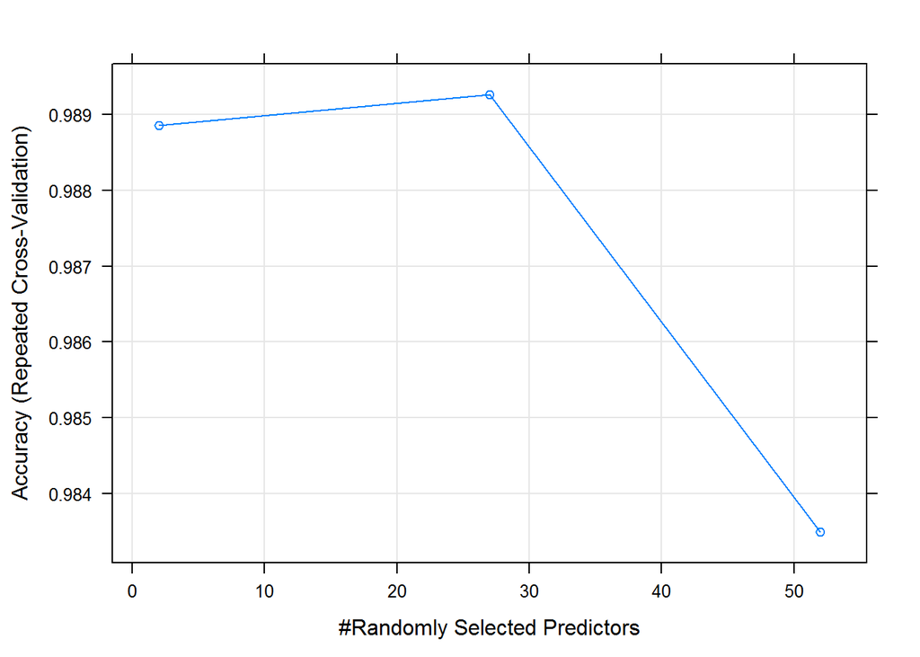

```r
plot(rfH)
```

##### Visual inspection of the importance of variables, the map created using random forest

```r
dm <- as.matrix(varImp(rfH$finalMode))
```

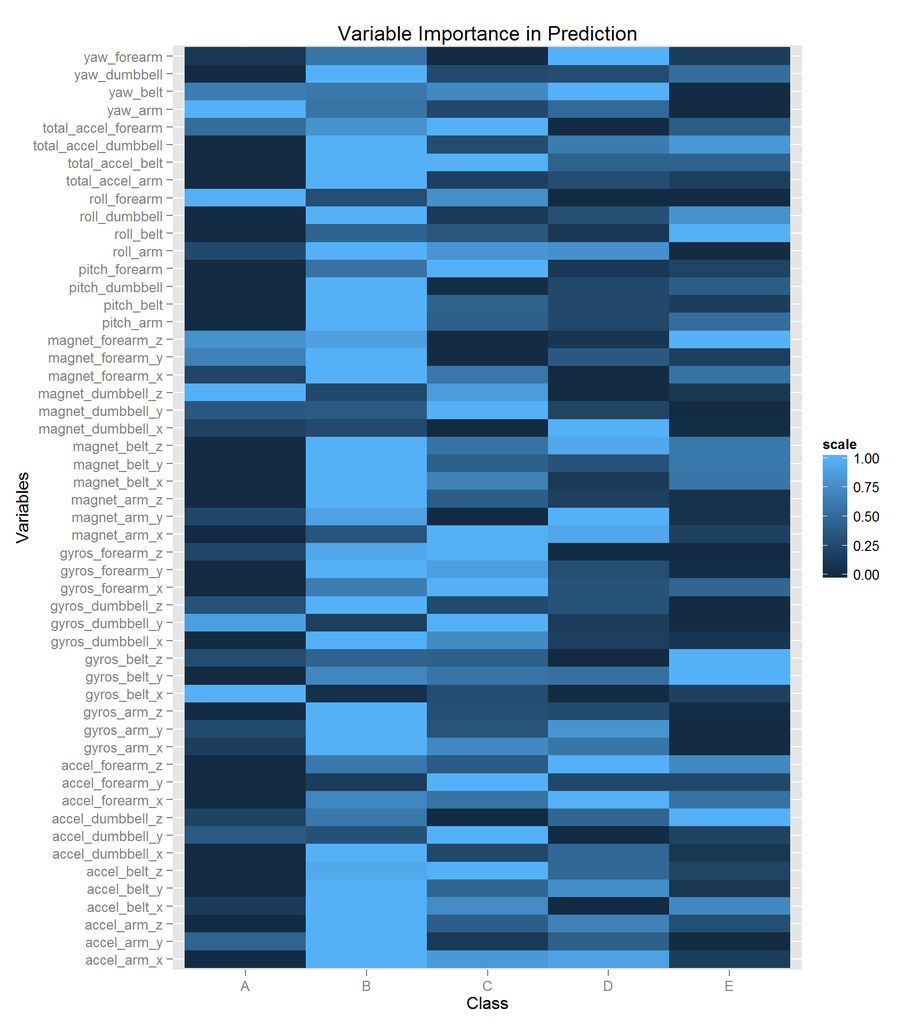

```r
dm1 <- dm[1:52,]
dm2 <- melt(dm1, id=c("row.names"))
dm3 <- ddply(dm2, .(X1), transform, scale = rescale(value))
p <- ggplot(dm3, aes(X2,X1)) + geom_tile(aes(fill = scale))
p <- p+ggtitle("Variable Importance in Prediction")
p <- p+ylab("Variables") +xlab("Class")
p
```

##### training using neural networks

```r
nnetH <- train(classe ~ .,data=trainTransformedf[,2:54],
               method = "nnet",tuneLength = 2,
               trControl = fitControl,linout=FALSE,trace=FALSE)
```

##### training using knn , model was trained for 5 nearest neigbour

```r
knnH <- train(classe ~ .,data=trainTransformedf[,2:54],
              method = "knn",
              tuneLength = 2,
              trControl = fitControl)
```

##### training using Support Vector machine

```r
svmH <- train(classe ~ .,data=trainTransformedf[,2:54], method = "svmRadialCost", trControl = fitControl)
```

```r
prednnetHTr <- predict(nnetH,trainTransformedf[,2:53])
prednnetHTe <- predict(nnetH,testTransformedf[,2:53])


predknnHTr <- predict(knnH,trainTransformedf[,2:53])
predknnHTe <- predict(knnH,testTransformedf[,2:53])

predsvrHTr <- predict(svmH,trainTransformedf[,2:53])
predsvrHTe <- predict(svmH,testTransformedf[,2:53])

predrfHTr <- predict(rfH,trainTransformedf[,2:53])
predrfHTe <- predict(rfH,testTransformedf[,2:53])
```

##### combining all the four model based on majority voting.

The class appearing the most in a row was selected as the predicted class

```r
preDFH <- data.frame(prednnetHTe,predknnHTe,predsvrHTe,predrfHTe)
df1 <- data.frame()
df3 <- data.frame()
for (i in 1:nrow(preDFH)) {
  a <- preDFH[i,]=='A'
  b <- preDFH[i,]=='B'
  c <- preDFH[i,]=='C'
  d <- preDFH[i,]=='D'
  d <- preDFH[i,]=='D'
  e <- preDFH[i,]=='E'
  df <- data.frame(length(which(a)),length(which(b)),length(which(c)),length(which(d)),length(which(e)))
  df1 <- rbind(df1,df)
}

df3 <- apply(df1,1,function(x) which.max(x))
df3[df3==1]<-'A'
df3[df3==2]<-'B'
df3[df3==3]<-'C'
df3[df3==4]<-'D'
df3[df3==5]<-'E'
ensmbStackH <- data.frame(df3)
```

```r
# Comparison between insample and out sample accuracy
confusionMatrix(trainTransformedf[,54],prednnetHTr)
confusionMatrix(testTransformedf[,54],prednnetHTe)

confusionMatrix(trainTransformedf[,54],predknnHTr)
confusionMatrix(testTransformedf[,54],predknnHTe)


confusionMatrix(trainTransformedf[,54],predsvrHTr)
confusionMatrix(testTransformedf[,54],predsvrHTe)
```

[output not shown]

##### Random Forest insample vs out sample accuracy

```r
#in sample
confusionMatrix(trainTransformedf[,54],predrfHTr)
```

```
## Confusion Matrix and Statistics
##
##           Reference
## Prediction    A    B    C    D    E
##          A 4185    0    0    0    0
##          B    0 2848    0    0    0
##          C    0    0 2567    0    0
##          D    0    0    0 2412    0
##          E    0    0    0    0 2706
##
## Overall Statistics
##
##                Accuracy : 1
##                  95% CI : (0.9997, 1)
##     No Information Rate : 0.2843
##     P-Value [Acc > NIR] : < 2.2e-16
##
##                   Kappa : 1
##  Mcnemar's Test P-Value : NA
##
## Statistics by Class:
##
##                      Class: A Class: B Class: C Class: D Class: E
## Sensitivity            1.0000   1.0000   1.0000   1.0000   1.0000
## Specificity            1.0000   1.0000   1.0000   1.0000   1.0000
## Pos Pred Value         1.0000   1.0000   1.0000   1.0000   1.0000
## Neg Pred Value         1.0000   1.0000   1.0000   1.0000   1.0000
## Prevalence             0.2843   0.1935   0.1744   0.1639   0.1839
## Detection Rate         0.2843   0.1935   0.1744   0.1639   0.1839
## Detection Prevalence   0.2843   0.1935   0.1744   0.1639   0.1839
## Balanced Accuracy      1.0000   1.0000   1.0000   1.0000   1.0000
```

```r
# out of sample
confusionMatrix(testTransformedf[,54],predrfHTe)
```

```
## Confusion Matrix and Statistics
##
##           Reference
## Prediction    A    B    C    D    E
##          A 1395    0    0    0    0
##          B    7  939    3    0    0
##          C    0    6  846    3    0
##          D    0    1    9  793    1
##          E    0    0    1    0  900
##
## Overall Statistics
##
##                Accuracy : 0.9937
##                  95% CI : (0.991, 0.9957)
##     No Information Rate : 0.2859
##     P-Value [Acc > NIR] : < 2.2e-16
##
##                   Kappa : 0.992
##  Mcnemar's Test P-Value : NA
##
## Statistics by Class:
##
##                      Class: A Class: B Class: C Class: D Class: E
## Sensitivity            0.9950   0.9926   0.9849   0.9962   0.9989
## Specificity            1.0000   0.9975   0.9978   0.9973   0.9998
## Pos Pred Value         1.0000   0.9895   0.9895   0.9863   0.9989
## Neg Pred Value         0.9980   0.9982   0.9968   0.9993   0.9998
## Prevalence             0.2859   0.1929   0.1752   0.1623   0.1837
## Detection Rate         0.2845   0.1915   0.1725   0.1617   0.1835
## Detection Prevalence   0.2845   0.1935   0.1743   0.1639   0.1837
## Balanced Accuracy      0.9975   0.9950   0.9913   0.9968   0.9993
```

##### Comparison between models accuracy

```r
confusionMatrix(testTransformedf[,54],prednnetHTe)
confusionMatrix(testTransformedf[,54],predknnHTe)
confusionMatrix(testTransformedf[,54],predsvrHTe)
```

[output not shown]

##### comparison between Random Forest and Ensemble

```r
confusionMatrix(testTransformedf[,54],predrfHTe)
```

```
## Confusion Matrix and Statistics
##
##           Reference
## Prediction    A    B    C    D    E
##          A 1395    0    0    0    0
##          B    7  939    3    0    0
##          C    0    6  846    3    0
##          D    0    1    9  793    1
##          E    0    0    1    0  900
##
## Overall Statistics
##
##                Accuracy : 0.9937
##                  95% CI : (0.991, 0.9957)
##     No Information Rate : 0.2859
##     P-Value [Acc > NIR] : < 2.2e-16
##
##                   Kappa : 0.992
##  Mcnemar's Test P-Value : NA
##
## Statistics by Class:
##
##                      Class: A Class: B Class: C Class: D Class: E
## Sensitivity            0.9950   0.9926   0.9849   0.9962   0.9989
## Specificity            1.0000   0.9975   0.9978   0.9973   0.9998
## Pos Pred Value         1.0000   0.9895   0.9895   0.9863   0.9989
## Neg Pred Value         0.9980   0.9982   0.9968   0.9993   0.9998
## Prevalence             0.2859   0.1929   0.1752   0.1623   0.1837
## Detection Rate         0.2845   0.1915   0.1725   0.1617   0.1835
## Detection Prevalence   0.2845   0.1935   0.1743   0.1639   0.1837
## Balanced Accuracy      0.9975   0.9950   0.9913   0.9968   0.9993
```

```r
confusionMatrix(testTransformedf[,54],ensmbStackH[,1])
```

```
## Confusion Matrix and Statistics
##
##           Reference
## Prediction    A    B    C    D    E
##          A 1393    2    0    0    0
##          B   86  861    2    0    0
##          C    3   21  830    1    0
##          D    0    2   64  737    1
##          E    2    2   34    9  854
##
## Overall Statistics
##
##                Accuracy : 0.9533
##                  95% CI : (0.947, 0.959)
##     No Information Rate : 0.3026
##     P-Value [Acc > NIR] : < 2.2e-16
##
##                   Kappa : 0.9408
##  Mcnemar's Test P-Value : NA
##
## Statistics by Class:
##
##                      Class: A Class: B Class: C Class: D Class: E
## Sensitivity            0.9387   0.9696   0.8925   0.9866   0.9988
## Specificity            0.9994   0.9781   0.9937   0.9839   0.9884
## Pos Pred Value         0.9986   0.9073   0.9708   0.9167   0.9478
## Neg Pred Value         0.9741   0.9932   0.9753   0.9976   0.9998
## Prevalence             0.3026   0.1811   0.1896   0.1523   0.1743
## Detection Rate         0.2841   0.1756   0.1692   0.1503   0.1741
## Detection Prevalence   0.2845   0.1935   0.1743   0.1639   0.1837
## Balanced Accuracy      0.9690   0.9738   0.9431   0.9852   0.9936
```

##### Final Model

```r
ouSampAcc <- confusionMatrix(testTransformedf[,54],predrfHTe)


ouSamperr <- paste(round((1-ouSampAcc$overall[1])*100,2),'%')

# The out of sample error for Randon Forest model is :-
print(ouSamperr)
```

```
## [1] "0.63 %"
```

###### Prediciting Cases for submission

```r
print(ensmbStackHfa)
```

```
##  [1] "B" "A" "B" "A" "A" "E" "D" "B" "A" "A" "B" "C" "B" "A" "E" "E" "A"
## [18] "B" "B" "B"
```